# Data-Driven Modeling of Temporal Dynamics in Gas Turbine Generators Using Machine Learning

## Abstract

Modeling dynamical systems is essential for understanding complex systems, particularly when the governing equations are either unavailable or inadequately parameterized, making it challenging to derive analytical models. Traditional system identification techniques primarily rely on input-output data; however, recent advancements in machine learning, particularly deep learning, have created new opportunities for modeling such systems. Despite their potential, deep learning models often suffer from limited interpretability, susceptibility to overfitting, and inconsistencies with physical laws. Incorporating prior knowledge of system physics into deep learning models has shown promise in mitigating these issues, yet identifying and effectively embedding such knowledge remains challenging. This paper proposes a robust alternative using a random forest regression (RFR) to model the system dynamics. The results demonstrate that by training the model using lagged endogenous and exogenous features, a Random Forest Regressor can achieve around 83% reduction in prediction error compared to an advanced deep learning model trained using knowledge of system physics. This approach is computationally efficient and highly effective, as demonstrated through its application to modeling the temporal dynamics of a gas turbine generator. These findings highlight the potential of classical machine learning techniques, such as a Random Forest Regressor, as an efficient alternatives for modeling complex dynamical systems.

[[Bielski at el.]](https://dl.acm.org/doi/10.1145/3632775.3661967) is used as a benchmark, incorporating the system's prior knowledge into training a recurrent neural network to predict the electrical output power of the gas turbine generator based on a sequence of time-series input control voltages. Using the same dataset as in the benchmark paper, the results of this project will be directly compared to draw meaningful conclusions. The dataset for this project, as well as the benchmark paper, is sourced from [[UCI Machine Learning Repository]](https://archive.ics.uci.edu/dataset/994/micro+gas+turbine+electrical+energy+prediction).

## Introduction

In science and engineering, a **"system"** is defined as a collection of components assembled to achieve a specific purpose. All the components in a system are unified through some kind of interdependence among them. They react with each other so that the system functions as a whole to serve a particular purpose. In a system, **"parameters"** are the fixed or time-variable quantities that characterize the system's structure or behavior. They typically define the properties or conditions under which the system operates. The variables that represent the state or behavior of various components within a system are referred to as a **"signal"**. They are called variables because they have the property to change or evolve over time.

**A dynamical system** is a system whose states change or evolve over time. These systems can be described in terms of:

**1. State Variables**: Quantities that define the system's state at any given time (e.g., position, velocity, temperature, voltage).

**2. Time Evolution**: How state variables evolve over time, typically defined by:

- **Ordinary Differential Equations (ODEs)**: For continuous-time systems.
- **Difference Equations**: For discrete-time systems.

**Some Examples of Dynamical Systems**:

- **Mechanical Systems**: A pendulum's motion is governed by Newton's laws of motion.
- **Electrical Systems**: An RLC circuit can be modeled using Kirchhoff’s laws, resulting in a set of differential equations.
- **Biological Systems**: Population dynamics in ecology (e.g., predator-prey models).
- **Economics**: Market dynamics and trends over time.
- **Power Systems**: Stability and control of microgrids and power networks.
- **Control Systems**: Robots or drones following a trajectory.

Modeling a dynamical system is a fundamental task in science and engineering, as it allows us to understand, predict, and control the behavior of systems that evolve. These systems can be described by mathematical equations that capture the relationships between the system's state, inputs, and outputs. Conventionally, dynamical systems are represented using application-specific theory-based models that describe their behavior through mathematical equations derived from physical principles. These models rely on the fundamental laws governing the system, such as Newtonian mechanics, thermodynamics, or Maxwell's equations, and are tailored to the specific domain of application.

Two drawbacks of the above approach are that, for complex dynamical systems, it may become challenging to:

- **Identify the Fundamental Laws Governing the System:** Many complex systems exhibit behaviors that are governed by intricate, nonlinear, or emergent phenomena, making it difficult to derive precise mathematical equations that fully capture their dynamics. This limitation is especially pronounced in domains where the underlying processes are not fully understood or are influenced by numerous interacting components.
- **Impractical or Excessively Expensive to Determine Internal Parameters:** For complex systems, the sheer number of parameters, coupled with the difficulty of measuring or estimating them, can make this approach infeasible. Experimental setups or simulations to determine these parameters may demand significant resources, time, or financial investment, rendering the modeling process excessively costly or impractical for large-scale or real-time applications.

A potential solution to this problem lies in machine learning methods, which offer a data-driven alternative to traditional theory-based models. By learning the behavior of dynamical systems directly from input-output data, these methods demonstrate flexibility and the ability to capture complex relationships, making them well-suited for modeling real-world systems. Specifically, many research papers in the literature emphasize the importance of utilizing artificial neural networks (ANNs) and Deep Learning (DL) to model complex input-output temporal dynamics. ANNs and DL are particularly well-suited for capturing the non-linear relationships and intricate dependencies between variables in dynamical systems. Their ability to approximate complex functions makes them a powerful tool for modeling systems where traditional methods struggle due to system complexity, high-dimensional interactions, or a lack of precise mathematical formulations. [[Manek at el.]](https://arxiv.org/abs/2001.06116)

However, despite recent successes, these methods also have the following shortcomings:

- If data availability is limited, ANN and DL models can produce physically inconsistent predictions. This means the results produced by these methods may not align well with the physical laws.
- Additionally, ANN and DL models can fall into the trap of overfitting and eventually struggle to generalize the data, which may cause poor prediction errors on the testing dataset.

To address the challenges of ANN and DL models producing physically inconsistent predictions and overfitting, several strategies can be implemented:

**1. Incorporating Physics-based Knowledge**

One effective way to solve the problem of physically inconsistent predictions is to integrate domain-specific knowledge and physical constraints directly into the machine learning model. This ensures that the model adheres to the fundamental physical laws governing the system. [[Wang at el.]](https://arxiv.org/abs/2107.01272), [[Robinson at el.]](https://arxiv.org/abs/2205.06858)

**2. Preventing Overfitting**

Overfitting occurs when the model learns not just the underlying patterns but also the noise in the training data, leading to poor generalization to unseen data. Several regularization techniques can be used to combat this:

- Cross-validation: Splitting the data into training and validation sets helps to identify overfitting early and optimize model performance.
- Regularization: Regularization techniques like L1 or L2 regularization penalize large model coefficients, which helps prevent the model from overfitting.
- Ensemble Learning: Using techniques such as random forests, boosting, or bagging (e.g., XGBoost, LightGBM) combines multiple models, which can help reduce variance and improve generalization. [[Acena at el.]](https://www.sciencedirect.com/science/article/pii/S0950705122008450?casa_token=iGz-qHtHnS4AAAAA:0E37EoT9Lh-1_OS-FOQTLwDpBplLNNh_cVcB2opK3d0q55oKcYwBwyIqK8qv1wJZXTRIeG0Bwkk)
- Dropout: In neural networks, dropout is a technique where random neurons are “dropped” (i.e., ignored) during training to prevent overfitting by making the network less reliant on any one feature.
- Early Stopping: Monitoring the performance on a validation set and stopping the training process when performance starts to degrade helps prevent the model from overfitting.

**3. Improved Data Quality**

Ensuring that the data used for training is of high quality and includes all relevant physical factors can mitigate both issues:

- Data Preprocessing: Proper feature engineering to capture the relevant dynamics and removing noise from the data can improve the model’s consistency and prevent overfitting.
- Domain-Specific Feature Engineering: Including physical features (e.g., temperature, pressure) that represent the physical system more accurately can help guide the model's predictions to stay consistent with physical laws.

**Incorporating Physics-based knowledge into Machine learning model:**

In many real-world applications, domain knowledge about the system's expected behavior can greatly enhance machine learning models. This concept, often termed Knowledge-Guided Machine Learning (KGML) or Physics-Informed Machine Learning (PIML), leverages prior insights to address the shortcomings of purely data-driven approaches, such as overfitting, lack of generalizability, or poor performance on sparse or noisy datasets. In practise, such physics-based knowledge is often readily available and can be utilized to enhance the performance of machine learning models. This knowledge comes from well-established theories, empirical relationships, or domain-specific laws that govern the system's behavior.

Several research papers have indeed highlighted the effectiveness of incorporating prior knowledge into machine learning models, especially Artificial Neural Networks (ANNs) and Deep Networks (DNs), by adding knowledge-guided constraints into the loss function. These constraints are typically in the form of regularization terms that directly embed domain-specific rules, physical laws, or empirical relationships into the model's training process. This approach significantly enhances the model's ability to generalize, improve performance, and remain consistent with known real-world behavior. [[Murlidhar at el.]](https://ieeexplore.ieee.org/document/8621955), [[Cuomo at el.]](https://link.springer.com/article/10.1007/s10915-022-01939-z), [[Jia at el.]](https://arxiv.org/abs/2001.11086)

Despite the availability of prior knowledge for dynamic systems, the process of identifying, modeling, and integrating new types of prior knowledge into data-driven models remains a complex and labor-intensive task. This is primarily due to the interdisciplinary nature of such tasks, which demands extensive collaboration among domain experts across different fields, such as physics, engineering, and data science. Furthermore, there is no guarantee that relevant prior knowledge is available or compatible with the specific dynamics-learning task at hand. Even if applicable knowledge exists, it may not always be in a form that is easily formalizable or suitable for direct integration into machine learning models. As a result, many potential sources of prior knowledge that could enhance dynamics-learning tasks remain underexplored in the current literature. [[Wang at el.]](https://arxiv.org/abs/2107.01272)

**Understanding Temporal Dynamics Problem Formulation:**

As explained earlier, a dynamical system can be categorized as either continuous or discrete, based on how it's states evolve over time. Discrete systems are governed by difference equations, which describe state changes at specific time intervals. These equations are valid only at discrete time steps, such as $t=0,1,2,…,n$. In contrast, continuous systems are described by differential equations, which capture state changes at every instant in the time domain, offering a continuous representation of system behavior. In practical engineering applications, systems are frequently modeled as discrete systems due to the resolution constraints of measurement data. Capturing the input-output behavior at an infinitesimally small time scale is not feasible, necessitating a discrete approximation that aligns with the available data's sampling intervals. **Temporal Dynamics** refers to the way in which a dynamical system evolves over time, capturing the progression and behavior of its states as influenced by governing equations and external factors.

Dynamical systems can also be classified as **linear** or **nonlinear** based on the nature of the governing equations. Linear systems are characterized by linear differential or difference equations, where the **principle of superposition** applies. In contrast, nonlinear systems are governed by nonlinear differential or difference equations, resulting in more complex dynamics, such as bifurcations, chaos, or limit cycles, which are not present in linear systems.

Suppose we consider a discrete-time dynamical system which is characterised by an unknown function: $$ y_t = f(u_t, u_{t-1}, \ldots, u_{t-N+1}) $$

Here, $u_t \in U $ is the input control signal at time $t$ and $y_t \in Y $ is the system output signal at time $t$. This mathematical representation shows that the system's output at a given time depends not only on the input at that time but also on previous input samples, typically spanning the last $N$ time steps. In dynamical systems, it's crucial to consider the system's memory — how past inputs influence the system's state at the current time. The relationship between the input and output might be more complex, involving feedback loops where past output values are also considered, thus incorporating both past inputs and outputs into the prediction or system's behavior. This concept is essential in various engineering fields, especially in control systems and time-series forecasting.

Specifically, a discrete-time dynamical system can be modeled as: $$ y_t = f(u_t, u_{t-1}, \ldots, u_{t-N+1}) + g(y_{t-1}, y_{t-2}, \ldots, y_{t-M}) $$

which means that the output at the current timestep $t$ depends not only on $N\in \mathbb{R}$ inputs but also on $M\in \mathbb{R}$ past outputs. The functions $f$ and $g$ can be linear as well as nonlinear, making the system capable of modeling complex relationships which are often observed in real-world systems like gas turbines. It is important to note that this is a general formulation, and not all dynamical systems exhibit memory effects that store past inputs and outputs, in which case the term $g$ would be zero.

The objective of temporal dynamics modeling using machine learning is to estimate an unknown function $f$ and $g$ through a parameterized function $\hat{f}_\theta$, where $ \theta \in \mathbb{R}^p$ represents the parameters of the model. The goal is to predict the output $y_t$ at time $t$, given a sequence of control inputs $( u_t, u_{t-1}, \dots, u_{t-N+1})$ and $(y_{t-1}, y_{t-2}, \dots, y_{t-M})$ from current and previous time steps. The model is trained to learn this mapping between the input sequence and the corresponding output, typically through supervised learning methods, where the model is optimized to minimize the prediction error over a set of training data.

**Importance of Gas Turbine Generators:**

Gas turbines are essential components in modern power and heat generation systems due to their versatility and efficiency. They serve several key functions, including:

- Meeting Peak Demand: Gas turbines can quickly ramp up or down to meet sudden increases in demand, which is crucial for maintaining grid stability.
- Providing Backup for Renewable Energy: They complement intermittent renewable energy sources such as solar and wind by offering backup power during periods of low generation or when these sources are unavailable.
- Decentralized Power Generation: Gas turbines can be deployed in decentralized setups, reducing transmission and conversion losses associated with long-distance power transport.

Gas turbines are widely recognized for their high efficiency, relatively low emissions when compared to other fossil fuel-based power generation systems, and their capacity to operate flexibly within various grid environments. These characteristics make gas turbines an essential component in the development of future cross-sector power-to-gas energy systems, which facilitate the conversion of electricity into gas, its storage and transportation, and the subsequent conversion of gas back into electricity. The ability of gas turbines to run on diverse fuel sources, including biofuels and hydrogen, positions them as key players in achieving net-zero carbon emissions while supporting sustainable and flexible energy solutions.

**Benchmark Model Methodology and Framework:**

A benchmark model is developed in [[Bielski at el.]](https://dl.acm.org/doi/10.1145/3632775.3661967) to capture the temporal dynamics of gas-turbine engines using input-output measurement data, aiming to predict output power (Watts) based on a sequence of input control voltage provided to the machine learning model. The dataset captures the relationship between the electrical power output (0-3000W) and a control input signal (0-10 volts) over timeframes ranging from seconds to hours. The dataset and research problem are described in greater detail in the Problem Statement section. This section is dedicated to understanding the benchmark model. The manuscript first discusses some potential drawbacks of modeling a dynamical system using Artificial Neural Networks (ANNs) and Deep Learning (DL) models without incorporating prior knowledge of the system's physics.

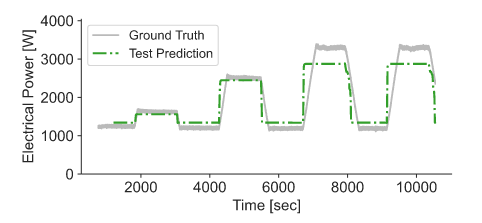

```python
from IPython.display import Image
Image('fig/figure1.png', width=600)
```

According to the manuscript, recurrent neural network (RNN) with Long Short-Term Memory (LSTM), when trained on a limited dataset, exhibits challenges in accurately modeling the system's behavior during both stationary and transitional phases. As illustrated in the figure above, the model’s predictions during stationary periods show significant deviations from the actual data. Furthermore, during transitional phases, the model fails to capture the gradual and smooth nature of transitions, instead producing predictions that are inconsistent with the expected physics of the system, particularly by not maintaining a constant gradient throughout the transition.

To solve this problem, [[Bielski at el.]](https://dl.acm.org/doi/10.1145/3632775.3661967) introduce and formalize a new form of prior knowledge crucial for data-driven modeling of temporal dynamics in engineering systems: **permissible system states**. The dynamical state of a system refers to a characteristic that evolves over time. Certain dynamical systems are constrained to a finite number of states, referred to as 'permissible system states,' which represent the set of allowable states the system can occupy. However, it is important to note that not all dynamical systems are limited to such permissible states. Domain expertise regarding the system can offer valuable insights into the existence of permissible system states and guide their representation and measurement. This type of knowledge defines the set of dynamic states that a system can safely occupy during its operation.

In temporal dynamics modeling, certain systems can be characterized by a finite set of permissible values for their **'output change rates'**. For example, the permissible system states may include three distinct output change rates, as illustrated below. Rising and falling transition phases typically exhibit a constant, non-zero output change rate, whereas stationary phases are characterized by a zero rate of change. The specific values of the change rates during transition phases can be derived from ground-truth data by estimating the derivative of the output signal over time. This form of prior knowledge is not exclusive to gas turbines; similar insights are often available for other dynamical systems in mechanical, thermal, or electrical engineering domains.

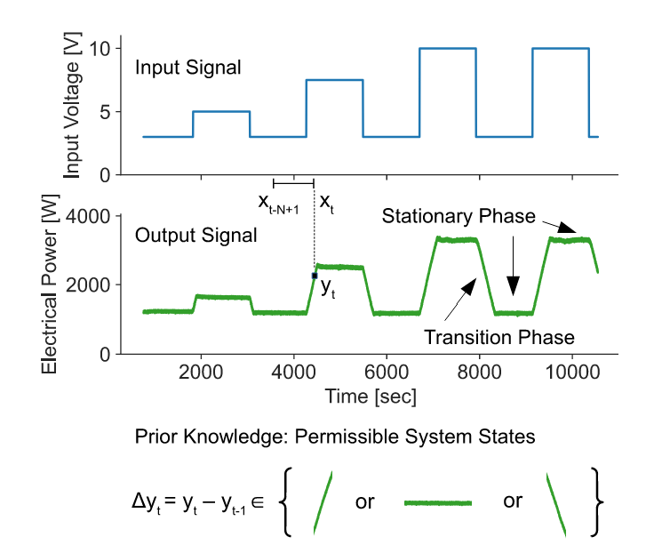

```python
from IPython.display import Image
Image('fig/figure2.png', width=600)
```

When training a machine learning model, deviations from these permissible states are penalized, effectively guiding the model to avoid behaviors that would be inconsistent with the system's real-world dynamics. Permissible system states could inform the model about expected rates of change in an output signal of a system. This knowledge is particularly beneficial when modeling how systems respond to input control signals, especially during transition phases where the output signal exhibits delayed reactions to rapid changes in the input. By incorporating permissible system states, machine learning models can better capture the dynamics of these systems while ensuring that their responses remain physically realistic and within expected bounds. This approach is a step forward in addressing the challenges of incorporating domain knowledge into complex system modeling, particularly for systems with delayed or nonlinear response.

The manuscript employs a regularization technique by incorporating prior knowledge into the loss function:

$$ \text{Loss} = \text{Loss}_{ML} + \lambda \cdot \text{Loss}_{MS} $$

$\text{Loss}_{ML}$ represents a conventional loss function such as Mean Squared Error (MSE): $$ \text{Loss}_{ML} = \frac{1}{T} \sum_{t=1}^{T} (y_t - \hat{y}_t)^2 $$

$\text{Loss}_{MS}$ represents the loss function, which is specifically designed to incorporate prior knowledge of the system. The hyperparameter $( \lambda_K \in \mathbb{R})$ determines its relative importance compared to $( \text{Loss}_{ML})$. Typically, $( \lambda_K)$ is determined through hyperparameter tuning.

[[Bielski at el.]](https://dl.acm.org/doi/10.1145/3632775.3661967) further introduce a novel method to incorporate permissible system states into ANNs and DL, because the existing knowledge-guided techniques do not allow integration of permissible system states into ANNs and DL. They propose a **multi-state constraint** that integrates this form of prior knowledge through a knowledge-guided loss function, which can be applied on top of any deep learning model. This method is flexible, supporting both exact and approximate prior knowledge. The latter is particularly useful in real-world scenarios where defining permissible states precisely is challenging due to uncertainties in measurements or the stochastic nature of the system. This innovation enables more accurate and robust modeling of complex systems, even in the face of imprecision in the prior knowledge, and can be employed across a variety of applications in engineering and dynamic system modeling.

In the manuscript, a model state $\tilde{s}_t$ is defined as a value or vector describing a characteristic of a machine learning model, such as it's output. . A set $S$ defined as a set of the permissible model states, represented as $S = \{ s_1, s_2, \dots, s_n \}$, where these states encode the prior knowledge that the model is expected to adhere to. It's assumed that a real valued distance $d(\cdot)$, such as Euclidean distance, can be computed between the model state $\tilde{s}_t$ and each element of set $S$. To integrate this knowledge into the model, a multi-state constraint term is incorporated into the loss function.

$\text{Loss}_{MS}$ can be implemented using the multi-state constraint as follows: $$ \text{Loss}_{MS} = \frac{1}{T} \sum_{t=1}^{T} \min_{i \in \{1, \dots, n\}} \beta_i \cdot d(\tilde{s}_t, s_i) $$ The loss term penalizes model states $\tilde{s}_t$ that do not belong to the set of permissible model states $S$, imposing a penalty that is proportional to the deviation from the closest permissible state. If $\tilde{s}_t$ exactly matches a permissible state, the penalty is zero.

In the manuscript, for gas turbines, prior knowledge takes a form of a finite set of the permissible values for the output change rates. To make the model state $\tilde{s}_t$ compatible with the notion of the change rates, the model state $\tilde{s}_t$ is defined as the difference between the two consecutive predictions as: $$ \tilde{s}_t = \Delta \hat{y}_t = \hat{y}_t - \hat{y}_{t-1} $$ Consequently, the set of permissible states is defined as $S = \{Δ₁, Δ₂, ..., Δₙ\}$, which represents the change rates for the two consecutive predictions of the model. The set of permissible differences is defined by estimating the derivative of the output signal over time, $\Delta y / \Delta t$, for the transition phases and assuming a difference of zero for the stationary phases. As a result, a set with three permissible differences are: $\Delta^+ = 6.388 \, \text{Ws}^{-1}$ for rising transitions, $\Delta^- = -6.388 \, \text{Ws}^{-1}$ for falling transitions, and $\Delta^0 = 0 \, \text{Ws}^{-1}$ for stationary phases.

Thus, the manuscript encodes the three permissible system states into the loss-function with the multi-state constraint by employing a squared euclidean distance to penalise deviations of the model's output from these states: $$ \text{Loss}_{MS} = \frac{1}{T} \sum_{t=2}^{T} \min \left( \beta^+ (\Delta \hat{y}_t - \Delta_+)^2, \beta^- (\Delta \hat{y}_t - \Delta_-)^2, \beta^0 (\Delta \hat{y}_t - \Delta_0)^2 \right) \ $$

This results in the following loss function: $$ \text{Loss} = \frac{1}{T} \sum_{t=1}^{T} (y_t - \hat{y}_t)^2 + \lambda \cdot (\frac{1}{T} \sum_{t=2}^{T} \min \left( \beta^+ (\Delta \hat{y}_t - \Delta_+)^2, \beta^- (\Delta \hat{y}_t - \Delta_-)^2, \beta^0 (\Delta \hat{y}_t - \Delta_0)^2 \right)) \ $$

**Benchmark Model's Performance:**

Using the above loss function, [[Bielski at el.]](https://dl.acm.org/doi/10.1145/3632775.3661967) trained a Recurrent Neural Network (RNN) model with Long Short-Term Memory (LSTM) units over six time series datasets and achieved a Root Mean Square Error (RMSE) of approximately 140W which represents the best performance. In addition, a simple RNN model utilizing LSTM layers was trained over six time series datasets without integrating prior knowledge into the loss function, resulting in a Root Mean Square Error (RMSE) of approximately 230W. They could achieve a significant reduction of around 40% in the prediction accuracy by incorporating prior knowledge. This highlights that integrating physics knowledge into the training process of the RNN can lead to a better prediction accuracy. The results are illustrated in the graph below:

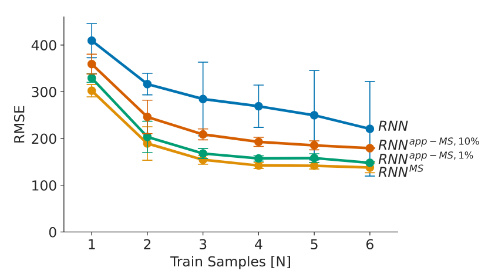

```python
from IPython.display import Image
Image('fig/figure3.png', width=600)
```

## Problem Statement

The primary objective of this project is to employ an interpretable and computationally efficient method, such as the random forest regressor, to predict the dynamic power output of a gas turbine engine generator based on a sequence of time-series control inputs. Additionally, the project aims to explore novel approaches to improve the random forest model's performance, with the goal of achieving a lower Root Mean Squared Error (RMSE) than the benchmark model [[Bielski at el.]](https://dl.acm.org/doi/10.1145/3632775.3661967), which currently achieves the best RMSE of 140W.

The gas-turbine generator considered in this project has a nominal power rating of 3000W, with a control input signal ranging from 0 to 10 volts. The dataset that is used in the project captures the relationship between the electrical power output (W) and the control input signal over timeframes ranging from seconds to hours. In general, the turbine generator exhibits steady-state behavior, where each input signal level corresponds to a constant power output. However, significant delays are observed during transitions in response to changes in the input signal, reflecting the system's transient dynamics. Furthermore, the turbine requires a continuous input signal to sustain power generation, as any disruption in the signal results in the cessation of operation. For the machine learning algorithm to achieve improved prediction accuracy, it must effectively capture these dynamic characteristics from the dataset.

Root Mean Squared Error (RMSE) is used as a performance metric to assess the accuracy of the machine learning model. The formula for RMSE is as follows:

$$ RMSE = \sqrt{\frac{1}{n} \sum_{i=1}^{n} (y_i - \hat{y}_i)^2} $$

Where:

- $ n $ is the number of test data points used for testing.
- $y_i $ is the actual value for the $ i $-th data point.
- $\hat{y}_i $ is the predicted value for the $ i $-th data point.
- $ \sum $ denotes the summation over all data points.

The state-of-the-art benchmark model's performance and accuracy were discussed in the previous section. The Root Mean Squared Error (RMSE) of the benchmark's model that uses Recurrent Neural Network (RNN) model, without incorporating any physics-informed knowledge, is approximately 230W. However, by integrating physics-informed knowledge, the model achieves a significantly improved RMSE of 140W.

**Importing Libraries**:

Here, we import the necessary libraries required for data processing and visualization.

```python
import os
import numpy as np
import pandas as pd
from sklearn.ensemble import RandomForestRegressor
from sklearn.metrics import mean_squared_error
from sklearn.model_selection import train_test_split, GridSearchCV
from sklearn.model_selection import train_test_split
from torch.utils.data import DataLoader, TensorDataset
from sklearn.preprocessing import StandardScaler
import matplotlib.pyplot as plt
import os
import torch
import torch.nn as nn
import torch.optim as optim
import seaborn as sns
%matplotlib inline
from sklearn.model_selection import train_test_split
import warnings
warnings.filterwarnings('ignore')
```

**Data Description and Visualization:**

Dataset is taken from UCI Machine Learning Repository: [Micro gas Turbine Electrical Energy Prediction](https://archive.ics.uci.edu/dataset/994/micro+gas+turbine+electrical+energy+prediction). There are 8 distinct datasets, each capturing a different set of input-output dynamics. The dataset consists of time-series data for both the input control signal (ranging from 0 to 10V) and the corresponding output (electrical power, ranging from 0 to 3000W). It includes eight distinct time series that capture the behavior of the gas turbine under various conditions. The duration of each time series varies from 6,495 to 11,820 data points, with a resolution of approximately 1 second, corresponding to a time span of around 1.8 to 3.3 hours. In total, the dataset comprises approximately 72,000 data points. Of the eight time series, six are employed for training the model, while the remaining two are used for testing its performance.

The following plots display all eight time series data.

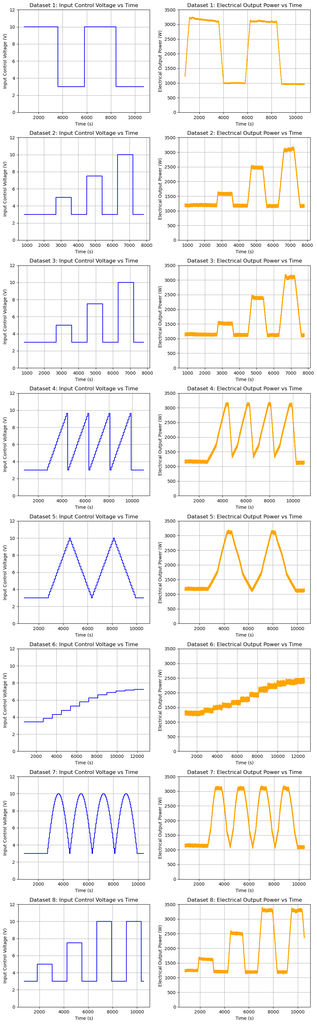

```python
import pandas as pd
import matplotlib.pyplot as plt

# List of file paths (replace these with your actual file names)
file_paths = ["data/train/ex_1.csv", "data/train/ex_20.csv", "data/train/ex_21.csv", "data/train/ex_23.csv",
              "data/train/ex_24.csv", "data/train/ex_9.csv", "data/test/ex_22.csv", "data/test/ex_4.csv"]

# Initialize subplots
fig, axes = plt.subplots(len(file_paths), 2, figsize=(10, 4 * len(file_paths)))  # Adjust figure size for compactness

for i, file_path in enumerate(file_paths):
    # Read CSV file
    data = pd.read_csv(file_path)

    # Extract columns
    time = data.iloc[:, 0]  # Time in seconds
    control_voltage = data.iloc[:, 1]  # Input control voltage
    electrical_power = data.iloc[:, 2]  # Output electrical power

    # Plot control voltage vs. time
    axes[i, 0].plot(time, control_voltage, label="Input Control Voltage", color='blue')
    axes[i, 0].set_title(f"Dataset {i + 1}: Input Control Voltage vs Time")
    axes[i, 0].set_xlabel("Time (s)")
    axes[i, 0].set_ylabel("Input Control Voltage (V)")
    axes[i, 0].set_ylim(0, 12)  # Set range for control voltage
    axes[i, 0].grid(True)

    # Plot electrical power vs. time
    axes[i, 1].plot(time, electrical_power, label="Electrical Output Power", color='orange')
    axes[i, 1].set_title(f"Dataset {i + 1}: Electrical Output Power vs Time")
    axes[i, 1].set_xlabel("Time (s)")
    axes[i, 1].set_ylabel("Electrical Output Power (W)")
    axes[i, 1].set_ylim(0, 3500)  # Set range for electrical power
    axes[i, 1].grid(True)

# Adjust layout for readability
plt.tight_layout()
plt.show()
```

Datasets 1 through 6 are utilized for training the model, while Datasets 7 and 8 are reserved for testing its performance.

## Methodology

**Case 1: Random Forest Regression with Exogenous Input**

A Random Forest Regressor (RFR) was employed as the predictive model due to its robustness to overfitting, ability to model non-linear relationships, and effectiveness in handling high-dimensional data. The RFR, configured with 100 decision trees and a fixed random seed for reproducibility, constructs multiple decision trees using bootstrap sampling and feature randomness to ensure model diversity and generalization. The dataset comprised time-series measurements of control voltage and corresponding gas turbine output power, with separate CSV files used for training and testing. A sliding window approach was adopted to frame the problem as supervised learning: for each time step $t$, the model received the past $N$ control voltage values i.e., $ u_{t-N}$ to $u_{t-1}$ as input and predicted the output power $ y_t$. The model was trained using sequence lengths of 100, 200, 300, 400, and 500 to identify the optimal dynamic order that best captures the system behavior. The training data was further split 80%--20% into training and validation sets. Model performance was evaluated using Root Mean Squared Error (RMSE) on both validation and test datasets.

**Case 2: Random Forest Regression with Endogenous Input**

The Random Forest Regressor (RFR), set up with 100 decision trees and a fixed random seed to maintain reproducibility, was also utilized to model the system using only past output values (endogenous inputs). In this configuration, the objective was to forecast the gas turbine's output power $ y_t$ based on its historical behavior. A sliding window technique was employed to transform the time-series data into input-output pairs: for each time index $ t $, a sequence of previous output values from $ y_{t-N}$ to $y_{t-1}$ was used as the input to estimate $ y_t$. The dataset comprised only the output power measurements and was organized into separate CSV files for training and testing. The sequence length $N$ was varied from 5 to 130 to determine the optimal model order for capturing the system’s dynamics. An 80%--20% split was applied to the training set for validation purposes. The model’s performance was quantified using the Root Mean Squared Error (RMSE) on both the validation and test datasets. The RFR demonstrated high accuracy and generalization capability, effectively capturing temporal patterns in the output signal without requiring external input variables.

## Results

All the cases discussed in the Methodology section have been implemented, and the Test RMSE values are displayed for each case. A final plot at the end of this section provides an overview of the entire project, summarizing the results and highlighting the performance of the model across different configurations.

**Case 1: Random Forest Regression with Exogenous Input**

```
Training model with time-sequence length: 100
Validation RMSE for time-sequence length 100: 192.47941525887762
Test RMSE for sequence length 100: 255.78282729277174
--------------------------------------------------
Training model with time-sequence length: 200
Validation RMSE for time-sequence length 200: 111.41226708256072
Test RMSE for sequence length 200: 187.08330764544428
--------------------------------------------------
Training model with time-sequence length: 300
Validation RMSE for time-sequence length 300: 78.96329306333837
Test RMSE for sequence length 300: 179.9048542282342
--------------------------------------------------
Training model with time-sequence length: 400
Validation RMSE for time-sequence length 400: 78.18066607398045
Test RMSE for sequence length 400: 201.6919482385782
--------------------------------------------------
Training model with time-sequence length: 500
Validation RMSE for time-sequence length 500: 79.65169026595032
Test RMSE for sequence length 500: 205.61468649931533
--------------------------------------------------
```

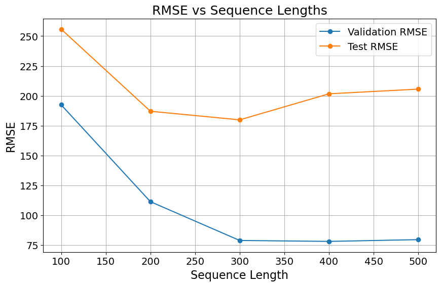

```python
import os
import numpy as np
import pandas as pd
from sklearn.ensemble import RandomForestRegressor
from sklearn.metrics import mean_squared_error
from sklearn.model_selection import train_test_split
import matplotlib.pyplot as plt

# Load the CSV data
def load_timeseries_data(folder_path):
    data = []
    for file_name in os.listdir(folder_path):
        # Only consider CSV files
        if file_name.endswith('.csv'):
            file_path = os.path.join(folder_path, file_name)
            df = pd.read_csv(file_path)
            data.append(df.values)  # Assuming relevant columns: [Index, Voltage, Power]
    return data

# Paths for the train and test datasets
train_path = "data/train"
test_path = "data/test"

# Load the train and test data
train_data = load_timeseries_data(train_path)
test_data = load_timeseries_data(test_path)

# Prepare the dataset
def prepare_dataset(data, sequence_length):
    X = []
    y = []
    for series in data:
        for i in range(sequence_length, len(series)):  # Start from the nth timestamp
            # Extract voltage for the current and previous sequence_length timestamps
            voltage_sequence = series[i-sequence_length+1:i, 1]  # Voltage values (second column)
            power_output = series[i, 2]  # Power value at the current timestamp (third column)

            X.append(voltage_sequence)
            y.append(power_output)

    return np.array(X), np.array(y)

# Sequence lengths to evaluate
sequence_lengths = [100, 200, 300, 400, 500]

# Initialize lists to store RMSE results
validation_rmse_list = []
test_rmse_list = []

# Loop through different sequence lengths
for seq_len in sequence_lengths:
    print(f"Training model with time-sequence length: {seq_len}")

    # Prepare the training and test datasets for the current sequence length
    X_train, y_train = prepare_dataset(train_data, seq_len)
    X_test, y_test = prepare_dataset(test_data, seq_len)

    # Split the training data for cross-validation
    X_train_split, X_val, y_train_split, y_val = train_test_split(X_train, y_train, test_size=0.2, random_state=42)

    # Create the Random Forest Regressor model
    rf_model = RandomForestRegressor(n_estimators=100, random_state=42)

    # Train the model
    rf_model.fit(X_train_split, y_train_split)

    # Make predictions on the validation set
    y_val_pred = rf_model.predict(X_val)

    # Evaluate model performance using RMSE
    val_rmse = np.sqrt(mean_squared_error(y_val, y_val_pred))
    print(f"Validation RMSE for time-sequence length {seq_len}: {val_rmse}")

    # Make predictions on the test set
    y_test_pred = rf_model.predict(X_test)

    # Evaluate on the test set
    test_rmse = np.sqrt(mean_squared_error(y_test, y_test_pred))
    print(f"Test RMSE for sequence length {seq_len}: {test_rmse}")
    print("-" * 50)

    # Store the RMSE results
    validation_rmse_list.append(val_rmse)
    test_rmse_list.append(test_rmse)

# Plot the RMSE values
plt.figure(figsize=(10, 6))
plt.plot(sequence_lengths, validation_rmse_list, label='Validation RMSE', marker='o')
plt.plot(sequence_lengths, test_rmse_list, label='Test RMSE', marker='o')
plt.title('RMSE vs Sequence Lengths', fontsize=18)
plt.xlabel('Sequence Length', fontsize=16)
plt.ylabel('RMSE', fontsize=16)
plt.xticks(fontsize=14)
plt.yticks(fontsize=14)
plt.legend(fontsize=14)
plt.grid()
plt.savefig("Exogenous_Input.png", dpi=300, bbox_inches='tight')
plt.show()
```

**Case 2: Random Forest Regression with Endogenous Input**

```
Training model with time-sequence length: 5
Validation RMSE for time-sequence length 5: 10.230801785703903
Test RMSE for sequence length 5: 27.88613837842928
--------------------------------------------------
Training model with time-sequence length: 10
Validation RMSE for time-sequence length 10: 9.811897004410659
Test RMSE for sequence length 10: 26.860628334466963
--------------------------------------------------
Training model with time-sequence length: 15
Validation RMSE for time-sequence length 15: 9.55799558054888
Test RMSE for sequence length 15: 26.867695430359163
--------------------------------------------------
Training model with time-sequence length: 20
Validation RMSE for time-sequence length 20: 9.922650395769846
Test RMSE for sequence length 20: 25.927721807713702
--------------------------------------------------
Training model with time-sequence length: 25
Validation RMSE for time-sequence length 25: 9.89577062227849
Test RMSE for sequence length 25: 25.101605373053992
--------------------------------------------------
Training model with time-sequence length: 30
Validation RMSE for time-sequence length 30: 9.967458253101837
Test RMSE for sequence length 30: 25.692447772670203
--------------------------------------------------
Training model with time-sequence length: 35
Validation RMSE for time-sequence length 35: 9.977330501318482
Test RMSE for sequence length 35: 26.277466586426048
--------------------------------------------------
Training model with time-sequence length: 40
Validation RMSE for time-sequence length 40: 9.594156086253317
Test RMSE for sequence length 40: 26.588575076764982
--------------------------------------------------
Training model with time-sequence length: 45
Validation RMSE for time-sequence length 45: 9.978043272073633
Test RMSE for sequence length 45: 27.185815684551365
--------------------------------------------------
Training model with time-sequence length: 50
Validation RMSE for time-sequence length 50: 9.59249998160229
Test RMSE for sequence length 50: 26.466714311021352
--------------------------------------------------
```

[output cut: 49 more lines]

```
Validation RMSE for time-sequence length 115: 9.993667859405932
Test RMSE for sequence length 115: 26.997916676676457
--------------------------------------------------
Training model with time-sequence length: 120
Validation RMSE for time-sequence length 120: 9.543019151164632
Test RMSE for sequence length 120: 27.35961856670176
--------------------------------------------------
Training model with time-sequence length: 125
Validation RMSE for time-sequence length 125: 9.846511604704851
Test RMSE for sequence length 125: 28.277284956362717
--------------------------------------------------
Training model with time-sequence length: 130
Validation RMSE for time-sequence length 130: 10.161310062211312
Test RMSE for sequence length 130: 26.995972976236477
--------------------------------------------------
```

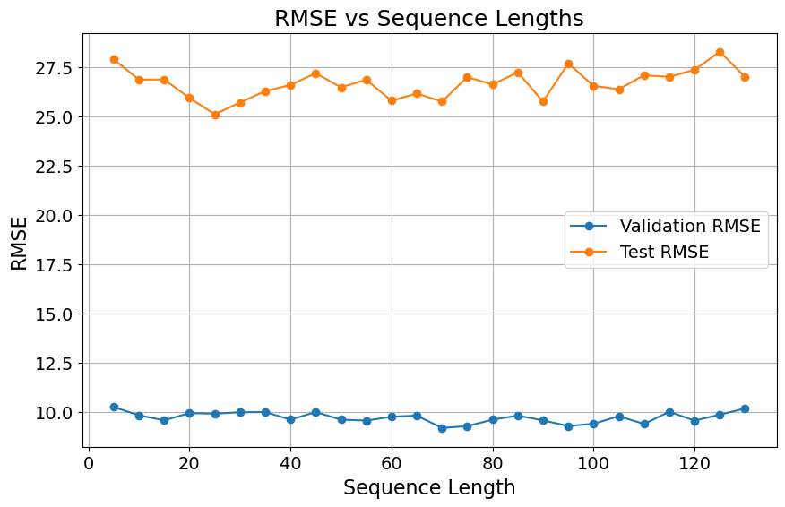

```python
import os
import numpy as np
import pandas as pd
from sklearn.ensemble import RandomForestRegressor
from sklearn.metrics import mean_squared_error
from sklearn.model_selection import train_test_split
import matplotlib.pyplot as plt

# Load the CSV data
def load_timeseries_data(folder_path):
    data = []
    for file_name in os.listdir(folder_path):
        # Only consider CSV files
        if file_name.endswith('.csv'):
            file_path = os.path.join(folder_path, file_name)
            df = pd.read_csv(file_path)
            data.append(df.values)  # Assuming relevant columns: [Index, Voltage, Power]
    return data

# Paths for the train and test datasets
train_path = "data/train"
test_path = "data/test"

# Load the train and test data
train_data = load_timeseries_data(train_path)
test_data = load_timeseries_data(test_path)

# Prepare the dataset
def prepare_dataset(data, sequence_length):
    X = []
    y = []
    for series in data:
        for i in range(sequence_length, len(series)):  # Start from the nth timestamp
            # Extract voltage for the current and previous sequence_length timestamps
            power_sequence = series[i-sequence_length+1:i, 2]  # power values (second column)
            power_output = series[i, 2]  # Power value at the current timestamp (third column)

            X.append(power_sequence)
            y.append(power_output)

    return np.array(X), np.array(y)

# Sequence lengths to evaluate
sequence_lengths = [5, 10, 15, 20, 25, 30, 35, 40, 45, 50, 55, 60, 65, 70, 75, 80, 85, 90, 95, 100, 105, 110, 115, 120, 125, 130]

# Initialize lists to store RMSE results
validation_rmse_list = []
test_rmse_list = []

# Loop through different sequence lengths
for seq_len in sequence_lengths:
    print(f"Training model with time-sequence length: {seq_len}")

    # Prepare the training and test datasets for the current sequence length
    X_train, y_train = prepare_dataset(train_data, seq_len)
    X_test, y_test = prepare_dataset(test_data, seq_len)

    # Split the training data for cross-validation
    X_train_split, X_val, y_train_split, y_val = train_test_split(X_train, y_train, test_size=0.2, random_state=42)

    # Create the Random Forest Regressor model
    rf_model = RandomForestRegressor(n_estimators=100, random_state=42)

    # Train the model
    rf_model.fit(X_train_split, y_train_split)

    # Make predictions on the validation set
    y_val_pred = rf_model.predict(X_val)

    # Evaluate model performance using RMSE
    val_rmse = np.sqrt(mean_squared_error(y_val, y_val_pred))
    print(f"Validation RMSE for time-sequence length {seq_len}: {val_rmse}")

    # Make predictions on the test set
    y_test_pred = rf_model.predict(X_test)

    # Evaluate on the test set
    test_rmse = np.sqrt(mean_squared_error(y_test, y_test_pred))
    print(f"Test RMSE for sequence length {seq_len}: {test_rmse}")
    print("-" * 50)

    # Store the RMSE results
    validation_rmse_list.append(val_rmse)
    test_rmse_list.append(test_rmse)

# Plot the RMSE values
plt.figure(figsize=(10, 6))
plt.plot(sequence_lengths, validation_rmse_list, label='Validation RMSE', marker='o')
plt.plot(sequence_lengths, test_rmse_list, label='Test RMSE', marker='o')
plt.title('RMSE vs Sequence Lengths', fontsize=18)
plt.xlabel('Sequence Length', fontsize=16)
plt.ylabel('RMSE', fontsize=16)
plt.xticks(fontsize=14)
plt.yticks(fontsize=14)
plt.legend(fontsize=14)
plt.grid()
plt.savefig("Endogenouss_Input.png", dpi=300, bbox_inches='tight')
plt.show()
```

**Case 3: Random Forest Regression with Endogenous and Exogenous Input**

```
Training with sequence length: 5, lag steps: 5
Validation RMSE: 10.1262, Test RMSE: 24.5648

Training with sequence length: 10, lag steps: 10
Validation RMSE: 9.9660, Test RMSE: 24.5947

Training with sequence length: 15, lag steps: 15
Validation RMSE: 9.7562, Test RMSE: 24.5455

Training with sequence length: 20, lag steps: 20
Validation RMSE: 10.1691, Test RMSE: 24.9748

Training with sequence length: 25, lag steps: 25
Validation RMSE: 10.1396, Test RMSE: 24.6020

Training with sequence length: 30, lag steps: 30
Validation RMSE: 10.2133, Test RMSE: 25.2267
```

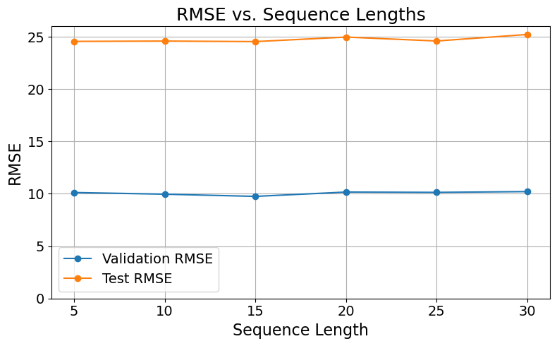

```python
import os
import numpy as np
import pandas as pd
import matplotlib.pyplot as plt
from sklearn.ensemble import RandomForestRegressor
from sklearn.metrics import mean_squared_error
from sklearn.model_selection import train_test_split

# Load CSV data
def load_timeseries_data(folder_path):
    data = []
    for file_name in os.listdir(folder_path):
        if file_name.endswith('.csv'):
            file_path = os.path.join(folder_path, file_name)
            df = pd.read_csv(file_path)
            data.append(df.values)  # Assuming [Index, Voltage, Power]
    return data

# Add lag features for power output
def add_lag_features(data, column_index, lag_steps):
    lagged_features = []
    for lag in range(1, lag_steps + 1):
        lagged_column = np.roll(data[:, column_index], shift=lag)
        lagged_column[:lag] = 0
        lagged_features.append(lagged_column)
    return np.column_stack(lagged_features)

# Prepare dataset with voltage sequences and lagged power outputs
def prepare_dataset_with_lags(data, sequence_length, lag_steps):
    X = []
    y = []
    for series in data:
        lagged_power = add_lag_features(series, column_index=2, lag_steps=lag_steps)
        for i in range(max(sequence_length, lag_steps), len(series)):
            voltage_sequence = series[i-sequence_length:i, 1]  # Voltage sequence
            power_output = series[i, 2]  # Target output
            features = np.concatenate([voltage_sequence, lagged_power[i-1]])  # Combine both
            X.append(features)
            y.append(power_output)
    return np.array(X), np.array(y)

# Paths
train_path = "data/train"
test_path = "data/test"

# Load data
train_data = load_timeseries_data(train_path)
test_data = load_timeseries_data(test_path)

# Define matching sequence lengths and lag steps
sequence_lag_pairs = [5, 10, 15, 20, 25, 30]

# Initialize lists to store RMSEs
val_rmses = []
test_rmses = []

# Loop through each (sequence=lag) pair
for sl in sequence_lag_pairs:
    seq_len = sl
    lag_steps = sl
    print(f"\nTraining with sequence length: {seq_len}, lag steps: {lag_steps}")

    # Prepare datasets
    X_train, y_train = prepare_dataset_with_lags(train_data, sequence_length=seq_len, lag_steps=lag_steps)
    X_test, y_test = prepare_dataset_with_lags(test_data, sequence_length=seq_len, lag_steps=lag_steps)

    # Train-validation split
    X_train_split, X_val, y_train_split, y_val = train_test_split(X_train, y_train, test_size=0.2, random_state=42)

    # Train Random Forest model
    rf_model = RandomForestRegressor(n_estimators=100, random_state=42)
    rf_model.fit(X_train_split, y_train_split)

    # Validation RMSE
    y_val_pred = rf_model.predict(X_val)
    val_rmse = np.sqrt(mean_squared_error(y_val, y_val_pred))
    val_rmses.append(val_rmse)

    # Test RMSE
    y_test_pred = rf_model.predict(X_test)
    test_rmse = np.sqrt(mean_squared_error(y_test, y_test_pred))
    test_rmses.append(test_rmse)

    print(f"Validation RMSE: {val_rmse:.4f}, Test RMSE: {test_rmse:.4f}")

# Plotting RMSE vs Sequence/Lag Steps
plt.figure(figsize=(8, 5))
plt.plot(sequence_lag_pairs, val_rmses, marker='o', label='Validation RMSE')
plt.plot(sequence_lag_pairs, test_rmses, marker='o', label='Test RMSE')
plt.xlabel("Sequence Length", fontsize=16)
plt.ylabel("RMSE", fontsize=16)
plt.title("RMSE vs. Sequence Lengths", fontsize=18)
plt.ylim(bottom=0)  # Start y-axis from 0
plt.grid(True)
plt.xticks(fontsize=14)
plt.yticks(fontsize=14)
plt.legend(fontsize=14)
plt.tight_layout()
plt.savefig("Endogenouss_Exogenous_Input.png", dpi=300, bbox_inches='tight')
plt.show()
```

**By incorporating lagged input and output features into the random forest regressor model, the test RMSE is significantly reduced to an impressive 24.54 Watts, showcasing exceptional performance. To the best of knowledge, no other model trained on such a large dataset has reported such a remarkably low RMSE in the existing literature.**

[figure not shown]

```python
import pandas as pd
import matplotlib.pyplot as plt
import seaborn as sns

# Data
data = {
    'Model': [
        "Reference [5]'s RNN Without Physics",
        "Random Forest (Exogenous)",
        "Reference [5]'s RNN With Physics",
        "Random Forest (Endogenous)",
        "Random Forest (Endogenous + Exogenous)"
    ],
    'Test RMSE (Watts)': [
        230,
        179.05,
        140,
        25.10,
        24.55
    ]
}

# Create DataFrame
df = pd.DataFrame(data)

# Sort by RMSE if desired (here we keep the order)
# df_sorted = df.sort_values(by='Test RMSE (Watts)', ascending=True)

# Plot settings
plt.figure(figsize=(12, 6))
sns.set_style("whitegrid")
barplot = sns.barplot(x='Model', y='Test RMSE (Watts)', data=df, palette='Blues_d')

# Annotate RMSE values on top of each bar
for p in barplot.patches:
    barplot.annotate(
        f"{p.get_height():.2f}",
        (p.get_x() + p.get_width() / 2, p.get_height()),
        ha='center', va='bottom',
        fontsize=22
    )

# Adjust labels, titles, and fonts
plt.xlabel('Model', fontsize=22)
plt.ylabel('Test RMSE (Watts)', fontsize=22)
plt.title('Comparison of Test RMSE across Different Models', fontsize=26, pad=20)
plt.xticks(rotation=30, ha='right', fontsize=22, wrap=True)
plt.yticks(fontsize=22)

plt.tight_layout()
plt.savefig("Final.png", dpi=300, bbox_inches='tight')
plt.show()
```

## Conclusion

This research explored various machine learning models, particularly those that are more classical and computationally efficient than deep learning models, to predict the performance of a system while minimizing the test RMSE (Root Mean Square Error). The results highlight significant advances in predictive accuracy, particularly when comparing the model performance with the benchmark models from [5].

Among the models evaluated, the Random Forest Regressor with lagged exogenous and endogenous input features outperformed all others, achieving an impressive Test RMSE of just 24.54 Watts, which, compared to others, is extremely close to 0. This result represents a substantial 82% reduction in test RMSE compared to the [5]’s performance, which recorded the best possible RMSE of 140 Watts after incorporating physics-based insights. This remarkable reduction underscores the effectiveness of incorporating lagged input and output features, enabling the model to capture temporal dependencies in the data and significantly improving predictive accuracy. To the best of knowledge, no other model trained on such a large dataset has reported such a remarkably low RMSE in the existing literature.

In contrast, the RNN model developed without prior knowledge in [5], achieved test RMSE values of 230 Watts. Although these models showed some improvement over traditional approaches, they were still outperformed by the random forest regressor trained solely on a sequence of exogenous inputs, which achieved an RMSE of around 179 Watts, reducing the prediction error by 22%. This suggests that even a traditional random forest regressor, trained solely on exogenous inputs, can still outperform deep learning methods in modeling dynamical systems.

From the results, it can be observed that the random forest regressor model trained solely on endogenous features outperformed the model trained using exogenous features. Moreover, the model trained with different sequences of the endogenous input exhibited stabilization, confirming that time sequences closer to the current timestamp contribute most significantly to the model's accuracy. Simply increasing the number of past time sequences of the endogenous variable does not substantially enhance performance.

This study highlights the significant benefits of incorporating temporal dependencies through endogenous and exogenous features for system state forecasting tasks. The achieved $\textbf{83\%}$ reduction in test RMSE demonstrates the potential of this approach to deliver highly accurate predictions. Furthermore, the random forest regressor with the best performance---trained using endogenous and exogenous features from 15 time sequences, achieving an RMSE of $\textbf{24.54 W}---$completed training in just \textbf{600 seconds}, offering superior computational efficiency compared to deep learning models, which often require several hours for training and testing.

These results imply that one of the key advantages of using endogenous and exogenous lagged features in a random forest regressor is the enhanced temporal understanding it provides. By accounting for the historical behavior of the system through past outputs, the model can improve its predictive accuracy, especially for systems where past behavior influences future states. This is crucial for systems with strong feedback mechanisms. Additionally, the inclusion of past outputs helps to improve the model’s overall performance. It enables the Random Forest Regressor to capture more complex patterns in the data, which may lead to better generalization to unseen test data. This can result in reduced overfitting and more accurate predictions, thereby improving key performance metrics such as RMSE. Moreover, this approach enhances the model's ability to handle feedback loops, where past states directly influence future states. By incorporating endogenous and exogenous features, the model becomes more robust to noise in the data and better at capturing the underlying patterns, which can increase its stability and predictive accuracy.

Overall, this research represents a significant step forward in predictive modeling of dynamical systems, setting a new benchmark for future work in this area. The findings suggest that further refinement of classical machine learning models, including hyperparameter optimization, additional temporal features, and domain-specific insights, could lead to even more accurate and reliable predictions in similar applications. This work can also be extended to a multi-step prediction problem in the future, where the primary task would be to predict the output over a sequence of future time steps based on the past sequence of input and output behaviors.